```r
library(tidyverse)
library(lubridate)
library(janitor)
```

```r
library(skimr)
library(ggplot2)
library(scales)
getwd()
```

```
## [1] "C:/Users/amsha/OneDrive/Documents"
```

```r
Daily_activity_1 <- read_csv("/Users/amsha/OneDrive/Documents/test/mturkfitbit_export_3.12.16-4.11.16/Fitabase Data 3.12.16-4.11.16/dailyActivity_merged.csv")
Daily_Activity_2 <- read_csv("/Users/amsha/OneDrive/Documents/test/mturkfitbit_export_4.12.16-5.12.16/Fitabase Data 4.12.16-5.12.16/dailyActivity_merged.csv")
Hourly_Calories_1 <- read_csv("/Users/amsha/OneDrive/Documents/test/mturkfitbit_export_3.12.16-4.11.16/Fitabase Data 3.12.16-4.11.16/hourlyCalories_merged.csv")
Hourly_Calories_2 <- read_csv("/Users/amsha/OneDrive/Documents/test/mturkfitbit_export_4.12.16-5.12.16/Fitabase Data 4.12.16-5.12.16/hourlyCalories_merged.csv")
Hourly_Steps_1 <- read_csv("/Users/amsha/OneDrive/Documents/test/mturkfitbit_export_3.12.16-4.11.16/Fitabase Data 3.12.16-4.11.16/hourlySteps_merged.csv")
Hourly_Steps_2 <- read_csv("/Users/amsha/OneDrive/Documents/test/mturkfitbit_export_4.12.16-5.12.16/Fitabase Data 4.12.16-5.12.16/hourlySteps_merged.csv")
Minute_Sleep_1 <- read_csv("/Users/amsha/OneDrive/Documents/test/mturkfitbit_export_3.12.16-4.11.16/Fitabase Data 3.12.16-4.11.16/minuteSleep_merged.csv")
Minute_Sleep_2 <- read_csv("/Users/amsha/OneDrive/Documents/test/mturkfitbit_export_4.12.16-5.12.16/Fitabase Data 4.12.16-5.12.16/minuteSleep_merged.csv")
Weight_log_1 <- read_csv("/Users/amsha/OneDrive/Documents/test/mturkfitbit_export_3.12.16-4.11.16/Fitabase Data 3.12.16-4.11.16/weightLogInfo_merged.csv")
Weight_Log_2 <- read_csv("/Users/amsha/OneDrive/Documents/test/mturkfitbit_export_4.12.16-5.12.16/Fitabase Data 4.12.16-5.12.16/weightLogInfo_merged.csv")
METs_1 <- read_csv("/Users/amsha/OneDrive/Documents/test/mturkfitbit_export_3.12.16-4.11.16/Fitabase Data 3.12.16-4.11.16/minuteMETsNarrow_merged.csv")
METs_2 <- read_csv("/Users/amsha/OneDrive/Documents/test/mturkfitbit_export_4.12.16-5.12.16/Fitabase Data 4.12.16-5.12.16/minuteMETsNarrow_merged.csv")
```

Data Exploration¶ Since the data is split across multiple spreadsheets—one for each month—I first needed to check the column names and dataset structure before merging them. This step ensures consistency across the datasets, allowing for accurate analysis in later stages.

**To prepare the Daily Activity data, I imported the two monthly files separately, checked for consistency in column names and formats, and then combined them using bind_rows(). I also converted the date column to proper date format and added a “Month” column to allow monthly trend comparisons.**

Daily Activity

```r
# Check column names and structure

colnames(Daily_activity_1)
```

```
##  [1] "Id"                       "ActivityDate"
##  [3] "TotalSteps"               "TotalDistance"
##  [5] "TrackerDistance"          "LoggedActivitiesDistance"
##  [7] "VeryActiveDistance"       "ModeratelyActiveDistance"
##  [9] "LightActiveDistance"      "SedentaryActiveDistance"
## [11] "VeryActiveMinutes"        "FairlyActiveMinutes"
## [13] "LightlyActiveMinutes"     "SedentaryMinutes"
## [15] "Calories"
```

```r
colnames(Daily_Activity_2)
```

```
##  [1] "Id"                       "ActivityDate"
##  [3] "TotalSteps"               "TotalDistance"
##  [5] "TrackerDistance"          "LoggedActivitiesDistance"
##  [7] "VeryActiveDistance"       "ModeratelyActiveDistance"
##  [9] "LightActiveDistance"      "SedentaryActiveDistance"
## [11] "VeryActiveMinutes"        "FairlyActiveMinutes"
## [13] "LightlyActiveMinutes"     "SedentaryMinutes"
## [15] "Calories"
```

```r
glimpse(Daily_activity_1)
```

```
## Rows: 457
## Columns: 15
## $ Id                       <dbl> 1503960366, 1503960366, 1503960366, 150396036…
## $ ActivityDate             <chr> "3/25/2016", "3/26/2016", "3/27/2016", "3/28/…
## $ TotalSteps               <dbl> 11004, 17609, 12736, 13231, 12041, 10970, 122…
## $ TotalDistance            <dbl> 7.11, 11.55, 8.53, 8.93, 7.85, 7.16, 7.86, 7.…
## $ TrackerDistance          <dbl> 7.11, 11.55, 8.53, 8.93, 7.85, 7.16, 7.86, 7.…
## $ LoggedActivitiesDistance <dbl> 0, 0, 0, 0, 0, 0, 0, 0, 0, 0, 0, 0, 0, 0, 0, …
## $ VeryActiveDistance       <dbl> 2.57, 6.92, 4.66, 3.19, 2.16, 2.36, 2.29, 3.3…
## $ ModeratelyActiveDistance <dbl> 0.46, 0.73, 0.16, 0.79, 1.09, 0.51, 0.49, 0.8…
## $ LightActiveDistance      <dbl> 4.07, 3.91, 3.71, 4.95, 4.61, 4.29, 5.04, 3.6…
## $ SedentaryActiveDistance  <dbl> 0.00, 0.00, 0.00, 0.00, 0.00, 0.00, 0.00, 0.0…
## $ VeryActiveMinutes        <dbl> 33, 89, 56, 39, 28, 30, 33, 47, 40, 15, 43, 3…
## $ FairlyActiveMinutes      <dbl> 12, 17, 5, 20, 28, 13, 12, 21, 11, 30, 18, 18…
## $ LightlyActiveMinutes     <dbl> 205, 274, 268, 224, 243, 223, 239, 200, 244, …
## $ SedentaryMinutes         <dbl> 804, 588, 605, 1080, 763, 1174, 820, 866, 636…
## $ Calories                 <dbl> 1819, 2154, 1944, 1932, 1886, 1820, 1889, 186…
```

```r
glimpse(Daily_Activity_2)
```

```
## Rows: 940
## Columns: 15
## $ Id                       <dbl> 1503960366, 1503960366, 1503960366, 150396036…
## $ ActivityDate             <chr> "4/12/2016", "4/13/2016", "4/14/2016", "4/15/…
## $ TotalSteps               <dbl> 13162, 10735, 10460, 9762, 12669, 9705, 13019…
## $ TotalDistance            <dbl> 8.50, 6.97, 6.74, 6.28, 8.16, 6.48, 8.59, 9.8…
## $ TrackerDistance          <dbl> 8.50, 6.97, 6.74, 6.28, 8.16, 6.48, 8.59, 9.8…
## $ LoggedActivitiesDistance <dbl> 0, 0, 0, 0, 0, 0, 0, 0, 0, 0, 0, 0, 0, 0, 0, …
## $ VeryActiveDistance       <dbl> 1.88, 1.57, 2.44, 2.14, 2.71, 3.19, 3.25, 3.5…
## $ ModeratelyActiveDistance <dbl> 0.55, 0.69, 0.40, 1.26, 0.41, 0.78, 0.64, 1.3…
## $ LightActiveDistance      <dbl> 6.06, 4.71, 3.91, 2.83, 5.04, 2.51, 4.71, 5.0…
## $ SedentaryActiveDistance  <dbl> 0, 0, 0, 0, 0, 0, 0, 0, 0, 0, 0, 0, 0, 0, 0, …
## $ VeryActiveMinutes        <dbl> 25, 21, 30, 29, 36, 38, 42, 50, 28, 19, 66, 4…
## $ FairlyActiveMinutes      <dbl> 13, 19, 11, 34, 10, 20, 16, 31, 12, 8, 27, 21…
## $ LightlyActiveMinutes     <dbl> 328, 217, 181, 209, 221, 164, 233, 264, 205, …
## $ SedentaryMinutes         <dbl> 728, 776, 1218, 726, 773, 539, 1149, 775, 818…
## $ Calories                 <dbl> 1985, 1797, 1776, 1745, 1863, 1728, 1921, 203…
```

```r
# Combine the two data frames

daily_activity_combined <- bind_rows(Daily_activity_1, Daily_Activity_2)

# Convert ActivityDate to Date formart

daily_activity_combined <- daily_activity_combined %>%
  mutate(ActivityDate = mdy(ActivityDate))

# Add a Month column for further analysis

daily_activity_combined <- daily_activity_combined %>%
  mutate(Month = month(ActivityDate, label = TRUE, abbr = TRUE))

# Remove duplicates if any

daily_activity_combined <- daily_activity_combined %>%
  distinct()

# Preview the first rows

head(daily_activity_combined)
```

```
## # A tibble: 6 × 16
##           Id ActivityDate TotalSteps TotalDistance TrackerDistance
##        <dbl> <date>            <dbl>         <dbl>           <dbl>
## 1 1503960366 2016-03-25        11004          7.11            7.11
## 2 1503960366 2016-03-26        17609         11.6            11.6
## 3 1503960366 2016-03-27        12736          8.53            8.53
## 4 1503960366 2016-03-28        13231          8.93            8.93
## 5 1503960366 2016-03-29        12041          7.85            7.85
## 6 1503960366 2016-03-30        10970          7.16            7.16
## # ℹ 11 more variables: LoggedActivitiesDistance <dbl>,
## #   VeryActiveDistance <dbl>, ModeratelyActiveDistance <dbl>,
## #   LightActiveDistance <dbl>, SedentaryActiveDistance <dbl>,
## #   VeryActiveMinutes <dbl>, FairlyActiveMinutes <dbl>,
## #   LightlyActiveMinutes <dbl>, SedentaryMinutes <dbl>, Calories <dbl>,
## #   Month <ord>
```

```r
# Validate total rows

nrow(Daily_activity_1) + nrow(Daily_Activity_2)
```

```
## [1] 1397
```

```r
nrow(daily_activity_combined)
```

```
## [1] 1397
```

The Daily Activity data was provided in two separate files for March and April. Since both data frames had consistent column names and structures, I combined them using bind_rows(). I also formatted the date column and created a new “Month” column to facilitate monthly comparisons. Finally, I removed any potential duplicate entries to ensure clean data for analysis.

```r
# Count unique users by Id

n_distinct(daily_activity_combined$Id)
```

```
## [1] 35
```

```r
daily_activity_combined %>%
  count(Id, name = "days_recorded") %>%
  arrange(desc(days_recorded))
```

```
## # A tibble: 35 × 2
##            Id days_recorded
##         <dbl>         <int>
##  1 4020332650            63
##  2 1503960366            50
##  3 1624580081            50
##  4 4445114986            46
##  5 4702921684            46
##  6 6962181067            45
##  7 1844505072            43
##  8 1927972279            43
##  9 2022484408            43
## 10 2026352035            43
## # ℹ 25 more rows
```

Hourly Calories

```r
# Check column names and structure

colnames(Hourly_Calories_1)
```

```
## [1] "Id"           "ActivityHour" "Calories"
```

```r
colnames(Hourly_Calories_2)
```

```
## [1] "Id"           "ActivityHour" "Calories"
```

```r
glimpse(Hourly_Calories_1)
```

```
## Rows: 24,084
## Columns: 3
## $ Id           <dbl> 1503960366, 1503960366, 1503960366, 1503960366, 150396036…
## $ ActivityHour <chr> "3/12/2016 12:00:00 AM", "3/12/2016 1:00:00 AM", "3/12/20…
## $ Calories     <dbl> 48, 48, 48, 48, 48, 48, 48, 48, 48, 49, 89, 134, 130, 81,…
```

```r
glimpse(Hourly_Calories_2)
```

```
## Rows: 22,099
## Columns: 3
## $ Id           <dbl> 1503960366, 1503960366, 1503960366, 1503960366, 150396036…
## $ ActivityHour <chr> "4/12/2016 12:00:00 AM", "4/12/2016 1:00:00 AM", "4/12/20…
## $ Calories     <dbl> 81, 61, 59, 47, 48, 48, 48, 47, 68, 141, 99, 76, 73, 66, …
```

```r
# Convert ActivityHour column to datetime format

Hourly_Calories_1 <- Hourly_Calories_1 %>%
  mutate(ActivityHour = str_trim(ActivityHour),
         ActivityHour = parse_date_time(ActivityHour, orders = "mdy HMS p"))

Hourly_Calories_2 <- Hourly_Calories_2 %>%
  mutate(ActivityHour = str_trim(ActivityHour),
         ActivityHour = parse_date_time(ActivityHour, orders = "mdy HMS p"))

# Combine both data frames
hourly_calories_combined <- bind_rows(Hourly_Calories_1, Hourly_Calories_2)


# Validate Total rows
nrow(Hourly_Calories_1) + nrow(Hourly_Calories_2)
```

```
## [1] 46183
```

```r
nrow(hourly_calories_combined)
```

```
## [1] 46183
```

```r
# Check for duplicated row
duplicated_rows_calories <- hourly_calories_combined %>%
  duplicated() %>%
  sum()
# Print the number of duplicated
print(duplicated_rows_calories)
```

```
## [1] 175
```

```r
# Remove duplicate entries

hourly_calories_combined <- hourly_calories_combined %>%
distinct()

nrow(Hourly_Calories_1) + nrow(Hourly_Calories_2)
```

```
## [1] 46183
```

```r
nrow(hourly_calories_combined)
```

```
## [1] 46008
```

```r
# Count unique users by Id
n_distinct(hourly_calories_combined$Id)
```

```
## [1] 35
```

```r
hourly_calories_combined %>%
  count(Id, name = "days_recorded") %>%
  arrange(desc(days_recorded))
```

```
## # A tibble: 35 × 2
##            Id days_recorded
##         <dbl>         <int>
##  1 1624580081          1480
##  2 1927972279          1480
##  3 2022484408          1480
##  4 2026352035          1480
##  5 4558609924          1480
##  6 2320127002          1479
##  7 4445114986          1479
##  8 8053475328          1479
##  9 8378563200          1479
## 10 8877689391          1479
## # ℹ 25 more rows
```

**The combined Hourly Calories dataset includes data from 35 unique users. The Hourly Calories data were combined after verifying that both datasets had consistent column names and formats. The ActivityHour column was converted to datetime format to ensure accurate time-based analysis. Duplicate entries were removed to avoid redundancy in the dataset.**

Hourly Steps

```r
colnames(Hourly_Steps_1)
```

```
## [1] "Id"           "ActivityHour" "StepTotal"
```

```r
colnames(Hourly_Steps_2)
```

```
## [1] "Id"           "ActivityHour" "StepTotal"
```

```r
glimpse(Hourly_Steps_1)
```

```
## Rows: 24,084
## Columns: 3
## $ Id           <dbl> 1503960366, 1503960366, 1503960366, 1503960366, 150396036…
## $ ActivityHour <chr> "3/12/2016 12:00:00 AM", "3/12/2016 1:00:00 AM", "3/12/20…
## $ StepTotal    <dbl> 0, 0, 0, 0, 0, 0, 0, 0, 0, 8, 551, 1764, 1259, 253, 4470,…
```

```r
glimpse(Hourly_Steps_2)
```

```
## Rows: 22,099
## Columns: 3
## $ Id           <dbl> 1503960366, 1503960366, 1503960366, 1503960366, 150396036…
## $ ActivityHour <chr> "4/12/2016 12:00:00 AM", "4/12/2016 1:00:00 AM", "4/12/20…
## $ StepTotal    <dbl> 373, 160, 151, 0, 0, 0, 0, 0, 250, 1864, 676, 360, 253, 2…
```

```r
# Convert ActivityHour to datetime format

Hourly_Steps_1 <- Hourly_Steps_1 %>%
  mutate(ActivityHour = str_trim(ActivityHour),
         ActivityHour = parse_date_time(ActivityHour, orders = "mdy HMS p"))

Hourly_Steps_2 <- Hourly_Steps_2 %>%
  mutate(ActivityHour = str_trim(ActivityHour),
         ActivityHour = parse_date_time(ActivityHour, orders = "mdy HMS p"))

# Combine the two datasets
hourly_steps_combined <- bind_rows(Hourly_Steps_1, Hourly_Steps_2)

# Check if number of rows matches
nrow(Hourly_Steps_1) + nrow(Hourly_Steps_2)
```

```
## [1] 46183
```

```r
nrow(hourly_steps_combined)
```

```
## [1] 46183
```

```r
# Check for duplicated row
duplicated_rows_steps <- hourly_steps_combined %>%
  duplicated() %>%
  sum()

# Print the number of duplicated
print(duplicated_rows_steps)
```

```
## [1] 175
```

```r
# Remove duplicated
hourly_steps_combined <- hourly_steps_combined %>%
  distinct()

# Check if number of rows matches
nrow(Hourly_Steps_1) + nrow(Hourly_Steps_2)
```

```
## [1] 46183
```

```r
nrow(hourly_steps_combined)
```

```
## [1] 46008
```

```r
# Count unique users by Id
n_distinct(hourly_steps_combined$Id)
```

```
## [1] 35
```

```r
hourly_steps_combined %>%
  count(Id, name = "days_recorded") %>%
  arrange(desc(days_recorded))
```

```
## # A tibble: 35 × 2
##            Id days_recorded
##         <dbl>         <int>
##  1 1624580081          1480
##  2 1927972279          1480
##  3 2022484408          1480
##  4 2026352035          1480
##  5 4558609924          1480
##  6 2320127002          1479
##  7 4445114986          1479
##  8 8053475328          1479
##  9 8378563200          1479
## 10 8877689391          1479
## # ℹ 25 more rows
```

**The combined Hourly Steps dataset includes data from 35 unique users. The Steps Calories data were combined after verifying that both datasets had consistent column names and formats. The ActivityHour column was converted to datetime format to ensure accurate time-based analysis. Duplicate entries were removed to avoid redundancy in the dataset.**

Minute Sleep

```r
# Check Column names

colnames(Minute_Sleep_1)
```

```
## [1] "Id"    "date"  "value" "logId"
```

```r
colnames(Minute_Sleep_2)
```

```
## [1] "Id"    "date"  "value" "logId"
```

```r
glimpse(Minute_Sleep_1)
```

```
## Rows: 198,559
## Columns: 4
## $ Id    <dbl> 1503960366, 1503960366, 1503960366, 1503960366, 1503960366, 1503…
## $ date  <chr> "3/13/2016 2:39:30 AM", "3/13/2016 2:40:30 AM", "3/13/2016 2:41:…
## $ value <dbl> 1, 1, 1, 1, 1, 1, 2, 2, 1, 1, 2, 2, 1, 1, 1, 1, 1, 1, 1, 1, 1, 1…
## $ logId <dbl> 11114919637, 11114919637, 11114919637, 11114919637, 11114919637,…
```

```r
glimpse(Minute_Sleep_2)
```

```
## Rows: 188,521
## Columns: 4
## $ Id    <dbl> 1503960366, 1503960366, 1503960366, 1503960366, 1503960366, 1503…
## $ date  <chr> "4/12/2016 2:47:30 AM", "4/12/2016 2:48:30 AM", "4/12/2016 2:49:…
## $ value <dbl> 3, 2, 1, 1, 1, 1, 1, 2, 2, 2, 3, 3, 3, 3, 3, 2, 1, 1, 1, 1, 1, 1…
## $ logId <dbl> 11380564589, 11380564589, 11380564589, 11380564589, 11380564589,…
```

```r
# Convert SleepMinute(date) to date time format
Minute_Sleep_1 <- Minute_Sleep_1 %>%
  mutate(date = mdy_hms(date))

Minute_Sleep_2 <- Minute_Sleep_2 %>%
  mutate(date = mdy_hms(date))

# Combine the two datasets
minute_sleep_combined <- bind_rows(Minute_Sleep_1, Minute_Sleep_2)

# Check if number of rows matches
nrow(Minute_Sleep_1) + nrow(Minute_Sleep_2)
```

```
## [1] 387080
```

```r
nrow(minute_sleep_combined)
```

```
## [1] 387080
```

```r
# Check for duplicated row
minute_sleep_duplicated <- minute_sleep_combined %>%
  duplicated() %>%
  sum()
# Print the number of duplicated
print(minute_sleep_duplicated)
```

```
## [1] 4300
```

```r
# Remove duplicated
minute_sleep_combined <- minute_sleep_combined %>%
  distinct()

# Check if number of rows matches
nrow(Minute_Sleep_1) + nrow(Minute_Sleep_2)
```

```
## [1] 387080
```

```r
nrow(minute_sleep_combined)
```

```
## [1] 382780
```

```r
# Count unique users by Id
n_distinct(minute_sleep_combined$Id)
```

```
## [1] 25
```

```r
minute_sleep_combined %>%
  count(Id, name = "days_recorded") %>%
  arrange(desc(days_recorded))
```

```
## # A tibble: 25 × 2
##            Id days_recorded
##         <dbl>         <int>
##  1 2026352035         32012
##  2 5553957443         29820
##  3 8378563200         29819
##  4 6962181067         28966
##  5 5577150313         25861
##  6 4319703577         25477
##  7 4702921684         24980
##  8 6117666160         22108
##  9 7086361926         21076
## 10 4445114986         20920
## # ℹ 15 more rows
```

**The combined Minute Sleep dataset includes data from 25 unique users. The minute-level sleep data were merged after confirming consistent column names and formats across both datasets. The date column was converted to datetime format to ensure accurate time-based analysis. Duplicate records were removed to maintain data integrity and avoid redundancy.**

Weight_Log_Info

```r
colnames(Weight_log_1)
```

```
## [1] "Id"             "Date"           "WeightKg"       "WeightPounds"
## [5] "Fat"            "BMI"            "IsManualReport" "LogId"
```

```r
colnames(Weight_Log_2)
```

```
## [1] "Id"             "Date"           "WeightKg"       "WeightPounds"
## [5] "Fat"            "BMI"            "IsManualReport" "LogId"
```

```r
glimpse(Weight_log_1)
```

```
## Rows: 33
## Columns: 8
## $ Id             <dbl> 1503960366, 1927972279, 2347167796, 2873212765, 2873212…
## $ Date           <chr> "4/5/2016 11:59:59 PM", "4/10/2016 6:33:26 PM", "4/3/20…
## $ WeightKg       <dbl> 53.3, 129.6, 63.4, 56.7, 57.2, 88.4, 92.4, 69.4, 99.7, …
## $ WeightPounds   <dbl> 117.5064, 285.7191, 139.7731, 125.0021, 126.1044, 194.8…
## $ Fat            <dbl> 22, NA, 10, NA, NA, NA, NA, NA, NA, NA, NA, NA, NA, NA,…
## $ BMI            <dbl> 22.97, 46.17, 24.77, 21.45, 21.65, 25.03, 35.01, 27.14,…
## $ IsManualReport <lgl> TRUE, FALSE, TRUE, TRUE, TRUE, TRUE, TRUE, TRUE, TRUE, …
## $ LogId          <dbl> 1.459901e+12, 1.460313e+12, 1.459728e+12, 1.459987e+12,…
```

```r
glimpse(Weight_Log_2)
```

```
## Rows: 67
## Columns: 8
## $ Id             <dbl> 1503960366, 1503960366, 1927972279, 2873212765, 2873212…
## $ Date           <chr> "5/2/2016 11:59:59 PM", "5/3/2016 11:59:59 PM", "4/13/2…
## $ WeightKg       <dbl> 52.6, 52.6, 133.5, 56.7, 57.3, 72.4, 72.3, 69.7, 70.3, …
## $ WeightPounds   <dbl> 115.9631, 115.9631, 294.3171, 125.0021, 126.3249, 159.6…
## $ Fat            <dbl> 22, NA, NA, NA, NA, 25, NA, NA, NA, NA, NA, NA, NA, NA,…
## $ BMI            <dbl> 22.65, 22.65, 47.54, 21.45, 21.69, 27.45, 27.38, 27.25,…
## $ IsManualReport <lgl> TRUE, TRUE, FALSE, TRUE, TRUE, TRUE, TRUE, TRUE, TRUE, …
## $ LogId          <dbl> 1.462234e+12, 1.462320e+12, 1.460510e+12, 1.461283e+12,…
```

```r
# Convert Date to datetime format

Weight_log_1 <- Weight_log_1 %>%
  mutate(Date = mdy_hms(Date))

Weight_Log_2 <- Weight_Log_2 %>%
  mutate(Date = mdy_hms(Date))

# Combine the two datasets
weight_log_combined <- bind_rows(Weight_log_1, Weight_Log_2)

# Check the number of rows
nrow(Weight_log_1) + nrow(Weight_Log_2)
```

```
## [1] 100
```

```r
nrow(weight_log_combined)
```

```
## [1] 100
```

```r
# Check for duplicated row
weight_log_duplicated <- weight_log_combined %>%
  duplicated() %>%
  sum()
# Print the number of duplicated
print(weight_log_duplicated)
```

```
## [1] 2
```

```r
#Remove duplicated rows
weight_log_combined <- weight_log_combined %>%
  distinct()

# Check the number of rows
nrow(Weight_log_1) + nrow(Weight_Log_2)
```

```
## [1] 100
```

```r
nrow(weight_log_combined)
```

```
## [1] 98
```

```r
# Count unique users by Id

n_distinct(weight_log_combined$Id)
```

```
## [1] 13
```

```r
weight_log_combined %>%
  count(Id, name = "days_recorded") %>%
  arrange(desc(days_recorded))
```

```
## # A tibble: 13 × 2
##            Id days_recorded
##         <dbl>         <int>
##  1 6962181067            43
##  2 8877689391            32
##  3 4558609924             6
##  4 2873212765             4
##  5 1503960366             3
##  6 1927972279             2
##  7 4319703577             2
##  8 2347167796             1
##  9 2891001357             1
## 10 4445114986             1
## 11 4702921684             1
## 12 5577150313             1
## 13 8253242879             1
```

**The combined Weight Log dataset includes data from 13 unique users. After confirming consistent column names and formats, the two datasets were merged. The Date column was converted to datetime format, and duplicates were removed. The Fat column contains missing values (NA), which were retained for completeness.**

METs

```r
colnames(METs_1)
```

```
## [1] "Id"             "ActivityMinute" "METs"
```

```r
colnames(METs_2)
```

```
## [1] "Id"             "ActivityMinute" "METs"
```

```r
glimpse(METs_1)
```

```
## Rows: 1,445,040
## Columns: 3
## $ Id             <dbl> 1503960366, 1503960366, 1503960366, 1503960366, 1503960…
## $ ActivityMinute <chr> "3/12/2016 12:00:00 AM", "3/12/2016 12:01:00 AM", "3/12…
## $ METs           <dbl> 10, 10, 10, 10, 10, 10, 10, 10, 10, 10, 10, 10, 10, 10,…
```

```r
glimpse(METs_2)
```

```
## Rows: 1,325,580
## Columns: 3
## $ Id             <dbl> 1503960366, 1503960366, 1503960366, 1503960366, 1503960…
## $ ActivityMinute <chr> "4/12/2016 12:00:00 AM", "4/12/2016 12:01:00 AM", "4/12…
## $ METs           <dbl> 10, 10, 10, 10, 10, 12, 12, 12, 12, 12, 12, 12, 10, 10,…
```

```r
# Convert ActivityMinute column to datetime format

METs_1 <- METs_1 %>%
  mutate(ActivityMinute = str_trim(ActivityMinute),
         ActivityMinute = parse_date_time(ActivityMinute, orders = "mdy HMS p"))

METs_2 <- METs_2 %>%
  mutate(ActivityMinute = str_trim(ActivityMinute),
         ActivityMinute = parse_date_time(ActivityMinute, orders = "mdy HMS p"))

# Combine both data frames
METs_combined <- bind_rows(METs_1, METs_2)


# Validate Total rows
nrow(METs_1) + nrow(METs_2)
```

```
## [1] 2770620
```

```r
nrow(METs_combined)
```

```
## [1] 2770620
```

```r
# Check for duplicated row
mets_duplicated <- METs_combined %>%
  duplicated() %>%
  sum()
# Print the number of duplicated
print(mets_duplicated)
```

```
## [1] 10500
```

```r
#Remove duplicated rows
METs_combined <- METs_combined %>%
  distinct()

# Validate Total rows
nrow(METs_1) + nrow(METs_2)
```

```
## [1] 2770620
```

```r
nrow(METs_combined)
```

```
## [1] 2760120
```

```r
# Count unique users by Id
n_distinct(METs_combined$Id)
```

```
## [1] 35
```

```r
METs_combined %>%
  count(Id, name = "days_recorded") %>%
  arrange(desc(days_recorded))
```

```
## # A tibble: 35 × 2
##            Id days_recorded
##         <dbl>         <int>
##  1 1624580081         88800
##  2 1927972279         88800
##  3 2026352035         88800
##  4 4558609924         88800
##  5 2022484408         88740
##  6 2320127002         88740
##  7 8053475328         88740
##  8 8877689391         88680
##  9 4445114986         88620
## 10 7086361926         88620
## # ℹ 25 more rows
```

The combined Minute METs dataset contains data from 35 unique users. The datasets were merged after confirming consistent formats. The ActivityMinute column was converted to datetime, and duplicates were removed.

Summary of Data Preparation The original dataset was described as containing data from 30 Fitbit users. However, after importing and cleaning the data, we identified a total of 35 unique users across the majority of the datasets.

Each file was examined and cleaned using a consistent process:

Column names and formats were verified and standardized. Datetime columns (e.g., ActivityHour, ActivityMinute) were converted to proper datetime objects using the mdy_hms(), mdy_hm(), or parse_date_time() functions to ensure accurate time-based analysis. Duplicated rows were identified and removed to avoid redundancy. Datasets were combined using bind_rows() after ensuring they had consistent structures. **Notable exceptions:

The Minute Sleep dataset contains data from 25 users. The Weight Log Info dataset contains data from only 13 users and includes missing values in the Fat column. Process

**Exploring Key Datasets

Initial exploration helps us understand the data structure and detect any inconsistencies. Summary statistics reveal possible outliers or missing data.

```r
# Previewing the cleaned datasets
head(daily_activity_combined)
```

```
## # A tibble: 6 × 16
##           Id ActivityDate TotalSteps TotalDistance TrackerDistance
##        <dbl> <date>            <dbl>         <dbl>           <dbl>
## 1 1503960366 2016-03-25        11004          7.11            7.11
## 2 1503960366 2016-03-26        17609         11.6            11.6
## 3 1503960366 2016-03-27        12736          8.53            8.53
## 4 1503960366 2016-03-28        13231          8.93            8.93
## 5 1503960366 2016-03-29        12041          7.85            7.85
## 6 1503960366 2016-03-30        10970          7.16            7.16
## # ℹ 11 more variables: LoggedActivitiesDistance <dbl>,
## #   VeryActiveDistance <dbl>, ModeratelyActiveDistance <dbl>,
## #   LightActiveDistance <dbl>, SedentaryActiveDistance <dbl>,
## #   VeryActiveMinutes <dbl>, FairlyActiveMinutes <dbl>,
## #   LightlyActiveMinutes <dbl>, SedentaryMinutes <dbl>, Calories <dbl>,
## #   Month <ord>
```

```r
head(hourly_calories_combined)
```

```
## # A tibble: 6 × 3
##           Id ActivityHour        Calories
##        <dbl> <dttm>                 <dbl>
## 1 1503960366 2016-03-12 00:00:00       48
## 2 1503960366 2016-03-12 01:00:00       48
## 3 1503960366 2016-03-12 02:00:00       48
## 4 1503960366 2016-03-12 03:00:00       48
## 5 1503960366 2016-03-12 04:00:00       48
## 6 1503960366 2016-03-12 05:00:00       48
```

```r
head(hourly_steps_combined)
```

```
## # A tibble: 6 × 3
##           Id ActivityHour        StepTotal
##        <dbl> <dttm>                  <dbl>
## 1 1503960366 2016-03-12 00:00:00         0
## 2 1503960366 2016-03-12 01:00:00         0
## 3 1503960366 2016-03-12 02:00:00         0
## 4 1503960366 2016-03-12 03:00:00         0
## 5 1503960366 2016-03-12 04:00:00         0
## 6 1503960366 2016-03-12 05:00:00         0
```

```r
head(METs_combined)
```

```
## # A tibble: 6 × 3
##           Id ActivityMinute       METs
##        <dbl> <dttm>              <dbl>
## 1 1503960366 2016-03-12 00:00:00    10
## 2 1503960366 2016-03-12 00:01:00    10
## 3 1503960366 2016-03-12 00:02:00    10
## 4 1503960366 2016-03-12 00:03:00    10
## 5 1503960366 2016-03-12 00:04:00    10
## 6 1503960366 2016-03-12 00:05:00    10
```

```r
head(minute_sleep_combined)
```

```
## # A tibble: 6 × 4
##           Id date                value       logId
##        <dbl> <dttm>              <dbl>       <dbl>
## 1 1503960366 2016-03-13 02:39:30     1 11114919637
## 2 1503960366 2016-03-13 02:40:30     1 11114919637
## 3 1503960366 2016-03-13 02:41:30     1 11114919637
## 4 1503960366 2016-03-13 02:42:30     1 11114919637
## 5 1503960366 2016-03-13 02:43:30     1 11114919637
## 6 1503960366 2016-03-13 02:44:30     1 11114919637
```

```r
head(weight_log_combined)
```

```
## # A tibble: 6 × 8
##          Id Date                WeightKg WeightPounds   Fat   BMI IsManualReport
##       <dbl> <dttm>                 <dbl>        <dbl> <dbl> <dbl> <lgl>
## 1    1.50e9 2016-04-05 23:59:59     53.3         118.    22  23.0 TRUE
## 2    1.93e9 2016-04-10 18:33:26    130.          286.    NA  46.2 FALSE
## 3    2.35e9 2016-04-03 23:59:59     63.4         140.    10  24.8 TRUE
## 4    2.87e9 2016-04-06 23:59:59     56.7         125.    NA  21.5 TRUE
## 5    2.87e9 2016-04-07 23:59:59     57.2         126.    NA  21.6 TRUE
## 6    2.89e9 2016-04-05 23:59:59     88.4         195.    NA  25.0 TRUE
## # ℹ 1 more variable: LogId <dbl>
```

```r
# Viewing column names
colnames(daily_activity_combined)
```

```
##  [1] "Id"                       "ActivityDate"
##  [3] "TotalSteps"               "TotalDistance"
##  [5] "TrackerDistance"          "LoggedActivitiesDistance"
##  [7] "VeryActiveDistance"       "ModeratelyActiveDistance"
##  [9] "LightActiveDistance"      "SedentaryActiveDistance"
## [11] "VeryActiveMinutes"        "FairlyActiveMinutes"
## [13] "LightlyActiveMinutes"     "SedentaryMinutes"
## [15] "Calories"                 "Month"
```

```r
colnames(hourly_calories_combined)
```

```
## [1] "Id"           "ActivityHour" "Calories"
```

```r
colnames(hourly_steps_combined)
```

```
## [1] "Id"           "ActivityHour" "StepTotal"
```

```r
colnames(METs_combined)
```

```
## [1] "Id"             "ActivityMinute" "METs"
```

```r
colnames(minute_sleep_combined)
```

```
## [1] "Id"    "date"  "value" "logId"
```

```r
colnames(weight_log_combined)
```

```
## [1] "Id"             "Date"           "WeightKg"       "WeightPounds"
## [5] "Fat"            "BMI"            "IsManualReport" "LogId"
```

```r
# Summary statistics of key variables
summary(daily_activity_combined %>% select(TotalSteps, TotalDistance, SedentaryMinutes))
```

```
##    TotalSteps    TotalDistance    SedentaryMinutes
##  Min.   :    0   Min.   : 0.000   Min.   :   0.0
##  1st Qu.: 3146   1st Qu.: 2.170   1st Qu.: 729.0
##  Median : 6999   Median : 4.950   Median :1057.0
##  Mean   : 7281   Mean   : 5.219   Mean   : 992.5
##  3rd Qu.:10544   3rd Qu.: 7.500   3rd Qu.:1244.0
##  Max.   :36019   Max.   :28.030   Max.   :1440.0
```

```r
summary(minute_sleep_combined$value)
```

```
##    Min. 1st Qu.  Median    Mean 3rd Qu.    Max.
##   1.000   1.000   1.000   1.091   1.000   3.000
```

```r
summary(weight_log_combined %>% select(WeightKg, BMI))
```

```
##     WeightKg           BMI
##  Min.   : 52.60   Min.   :21.45
##  1st Qu.: 61.50   1st Qu.:24.00
##  Median : 62.50   Median :24.39
##  Mean   : 72.47   Mean   :25.37
##  3rd Qu.: 85.25   3rd Qu.:25.59
##  Max.   :133.50   Max.   :47.54
```

Summary Statistics:

Average steps per day: 7,281 Average sedentary minutes: 992 Max sedentary time: 1440 minutes (entire day) Average weight: 72.5 kg BMI range: 21.45 to 47.54 In Sleep Minute data each row represents one minute of sleep. The values range from 1 to 3, likely indicating different sleep states (e.g., awake, light, deep). Merging Datasets

This combined dataset will allow us to explore the relationships between physical activity, steps and calories burned at an hourly level.

```r
# Joining hourly calories and steps for future comparion
hourly_combined <- left_join(hourly_steps_combined, hourly_calories_combined,
                             by = c("Id", "ActivityHour"))

# Preview merged dataset
head(hourly_combined)
```

```
## # A tibble: 6 × 4
##           Id ActivityHour        StepTotal Calories
##        <dbl> <dttm>                  <dbl>    <dbl>
## 1 1503960366 2016-03-12 00:00:00         0       48
## 2 1503960366 2016-03-12 01:00:00         0       48
## 3 1503960366 2016-03-12 02:00:00         0       48
## 4 1503960366 2016-03-12 03:00:00         0       48
## 5 1503960366 2016-03-12 04:00:00         0       48
## 6 1503960366 2016-03-12 05:00:00         0       48
```

```r
# Count unique users
n_distinct(hourly_combined$Id)
```

```
## [1] 35
```

```r
hourly_combined %>%
  count(Id, name = "days_recorded") %>%
  arrange(desc(days_recorded))
```

```
## # A tibble: 35 × 2
##            Id days_recorded
##         <dbl>         <int>
##  1 1624580081          1480
##  2 1927972279          1480
##  3 2022484408          1480
##  4 2026352035          1480
##  5 4558609924          1480
##  6 2320127002          1479
##  7 4445114986          1479
##  8 8053475328          1479
##  9 8378563200          1479
## 10 8877689391          1479
## # ℹ 25 more rows
```

Creating New Variable

In this step, we will enhance the daily activity and sleep datasets by adding date-related features, cleaning duplicates, and merging them to prepare for further analysis. This allows us to explore user behavior patterns across days and weeks. Transforming minutes into hours helps simplify analysis and makes trends easier to identify.

```r
# Adding weekday and week to daily activity
daily_activity_combined <- daily_activity_combined %>%
  mutate(ActivityDate = as.Date(ActivityDate),
         weekday = weekdays(ActivityDate),
         week = format(ActivityDate, "%Y-%U"),
         date = ActivityDate)

# Converting sleep duration from minutes to hours
daily_sleep_summary <- minute_sleep_combined %>%
  mutate(date = as.Date(date, format = "%m/%d/%Y")) %>%
  group_by(Id, date) %>%
  summarise(TotalMinutesAsleep = sum(value),
            SleepHours = sum(value) / 60,
            .groups = 'drop')

# Remove duplicate dates per user by aggregating
daily_activity_combined_clean <- daily_activity_combined %>%
  group_by(Id, date) %>%
  summarise(
    TotalSteps = sum(TotalSteps, na.rm = TRUE),
    TotalDistance = sum(TotalDistance, na.rm = TRUE),
    SedentaryMinutes = sum(SedentaryMinutes, na.rm = TRUE),
    VeryActiveMinutes = sum(VeryActiveMinutes, na.rm = TRUE),
    FairlyActiveMinutes = sum(FairlyActiveMinutes, na.rm = TRUE),
    LightlyActiveMinutes = sum(LightlyActiveMinutes, na.rm = TRUE),
    Calories = sum(Calories, na.rm = TRUE),
    weekday = first(weekday),
    week = first(week),
    .groups = "drop"
)

# Joining datasets - preserving all activity records
activity_sleep_merged <- left_join(daily_activity_combined_clean,
                                   daily_sleep_summary,
                                   by = c("Id", "date"))

# Previewing the result
head(activity_sleep_merged)
```

```
## # A tibble: 6 × 13
##        Id date       TotalSteps TotalDistance SedentaryMinutes VeryActiveMinutes
##     <dbl> <date>          <dbl>         <dbl>            <dbl>             <dbl>
## 1  1.50e9 2016-03-25      11004          7.11              804                33
## 2  1.50e9 2016-03-26      17609         11.6               588                89
## 3  1.50e9 2016-03-27      12736          8.53              605                56
## 4  1.50e9 2016-03-28      13231          8.93             1080                39
## 5  1.50e9 2016-03-29      12041          7.85              763                28
## 6  1.50e9 2016-03-30      10970          7.16             1174                30
## # ℹ 7 more variables: FairlyActiveMinutes <dbl>, LightlyActiveMinutes <dbl>,
## #   Calories <dbl>, weekday <chr>, week <chr>, TotalMinutesAsleep <dbl>,
## #   SleepHours <dbl>
```

```r
# Count unique users
n_distinct(activity_sleep_merged$Id)
```

```
## [1] 35
```

```r
activity_sleep_merged %>%
  count(Id, name = "days_recorded") %>%
  arrange(desc(days_recorded))
```

```
## # A tibble: 35 × 2
##            Id days_recorded
##         <dbl>         <int>
##  1 4020332650            62
##  2 1503960366            49
##  3 1624580081            49
##  4 4445114986            45
##  5 4702921684            45
##  6 6962181067            44
##  7 4319703577            43
##  8 1844505072            42
##  9 1927972279            42
## 10 2022484408            42
## # ℹ 25 more rows
```

```r
#Check for duplicated
activity_sleep_merged %>%
  count(Id, date) %>%
  filter(n > 1)
```

```
## # A tibble: 0 × 3
## # ℹ 3 variables: Id <dbl>, date <date>, n <int>
```

```r
hourly_combined %>%
  count(Id, ActivityHour) %>%
  filter(n > 1)
```

```
## # A tibble: 0 × 3
## # ℹ 3 variables: Id <dbl>, ActivityHour <dttm>, n <int>
```

```r
# Checking for missing values
sapply(weight_log_combined, function(x)sum(is.na(x)))
```

```
##             Id           Date       WeightKg   WeightPounds            Fat
##              0              0              0              0             94
##            BMI IsManualReport          LogId
##              0              0              0
```

```r
# Removing columns not needed for analysis
weight_log_combined <- weight_log_combined %>%
  select(-WeightPounds, -IsManualReport)

# Count unique users by Id
n_distinct(weight_log_combined$Id)
```

```
## [1] 13
```

```r
weight_log_combined %>%
  count(Id, name = "days_recorded") %>%
  arrange(desc(days_recorded))
```

```
## # A tibble: 13 × 2
##            Id days_recorded
##         <dbl>         <int>
##  1 6962181067            43
##  2 8877689391            32
##  3 4558609924             6
##  4 2873212765             4
##  5 1503960366             3
##  6 1927972279             2
##  7 4319703577             2
##  8 2347167796             1
##  9 2891001357             1
## 10 4445114986             1
## 11 4702921684             1
## 12 5577150313             1
## 13 8253242879             1
```

```r
# Final NA check
sapply(activity_sleep_merged, function(x) sum(is.na(x)))
```

```
##                   Id                 date           TotalSteps
##                    0                    0                    0
##        TotalDistance     SedentaryMinutes    VeryActiveMinutes
##                    0                    0                    0
##  FairlyActiveMinutes LightlyActiveMinutes             Calories
##                    0                    0                    0
##              weekday                 week   TotalMinutesAsleep
##                    0                    0                  740
##           SleepHours
##                  740
```

```r
sapply(METs_combined, function(x)sum(is.na(x)))
```

```
##             Id ActivityMinute           METs
##              0              0              0
```

```r
sapply(hourly_combined, function(x) sum(is.na(x)))
```

```
##           Id ActivityHour    StepTotal     Calories
##            0            0            0            0
```

Results:

No missing values found in mets_combined and hourly_combined 740 missing values were found in the TotalMinutesAsleep and SleepHours colmuns. These missing sleep values are expected — they represent days when users either didn’t wear the sleep tracker or it failed to record. Using left_join() preserved all activity data, even if sleep was not recorded, which is the correct approach for a comprehensive analysis.

Creating Tables for Average Steps and Sleep by Weekday

```r
# Average steps per weekday
avg_steps_weekday <- activity_sleep_merged %>%
  group_by(weekday) %>%
  summarise(avg_steps = mean(TotalSteps, na.rm = TRUE)) %>%
  arrange(match(weekday, c("Sunday","Monday","Tuesday","Wednesday","Thursday","Friday", "Saturday")))

# Average sleep hours per weekday
avg_sleep_weekday <- activity_sleep_merged %>%
  group_by(weekday) %>%
  summarise(avg_sleep_hours = mean(SleepHours, na.rm = TRUE)) %>%
  arrange(match(weekday, c("Sunday","Monday","Tuesday","Wednesday","Thursday","Friday", "Saturday")))

# Preview of Results

head(avg_steps_weekday)
```

```
## # A tibble: 6 × 2
##   weekday   avg_steps
##   <chr>         <dbl>
## 1 Sunday        6607.
## 2 Monday        7541.
## 3 Tuesday       7929.
## 4 Wednesday     7548.
## 5 Thursday      7268.
## 6 Friday        7188.
```

```r
head(avg_sleep_weekday)
```

```
## # A tibble: 6 × 2
##   weekday   avg_sleep_hours
##   <chr>               <dbl>
## 1 Sunday               8.84
## 2 Monday               7.30
## 3 Tuesday              7.31
## 4 Wednesday            8.10
## 5 Thursday             7.13
## 6 Friday               7.44
```

Summary of Data Process¶ This section outlines the steps taken to prepare the datasets for analysis, ensuring data integrity, consistency, and readiness for exploration.

1. Explored and Previewed the Datasets Used head() and colnames() to inspect the structure of each dataset. Reviewed summary statistics for key variables such as steps, sedentary time, and weight.
2. Merged Relevant Datasets Combined Hourly_Steps_Combined and Hourly_Calories_Combined into a single dataset (hourly_combined) using left_join() by Id and ActivityHour. Merged daily activity and sleep datasets (daily_activity_combined and daily_sleep_summary) to form activity_sleep_merged, preserving all activity data even when sleep data was missing.
3. Created New Time-Based Variables Added weekday and week columns based on the activity date to support temporal analyses. Converted total sleep duration from minutes to hours for easier interpretation.
4. Handled Duplicates Identified and removed duplicated records based on Id and date in the daily datasets using group_by() and summarise().
5. Checked for Missing Values Detected missing values in the SleepHours and TotalMinutesAsleep columns—740 values in total—due to users not tracking sleep every day. No missing values found in mets_combined and hourly_combined. Weight log had some missing values in the Fat column, which were retained for transparency during interpretation.
6. Cleaned and Aggregated Data Removed unnecessary columns such as WeightPounds and IsManualReport from the weight log dataset. Aggregated daily activity data to ensure one record per user per day.
7. Created Summary Tables Generated summary tables for: Average daily steps by weekday (avg_steps_weekday) Average sleep hours by weekday (avg_sleep_weekday) These tables enable insights into weekly behavioral patterns, supporting targeted wellness recommendations. Analyze and Share In this phase, the processed data is explored to generate insights that help answer the business questions defined in the ‘Ask’ phase. The analysis begins by addressing the first question: What are some trends in smart device usage?

Physical Activity Levels by Weekday

We want to understand user activity patterns across weekdays, grouped by activity type.

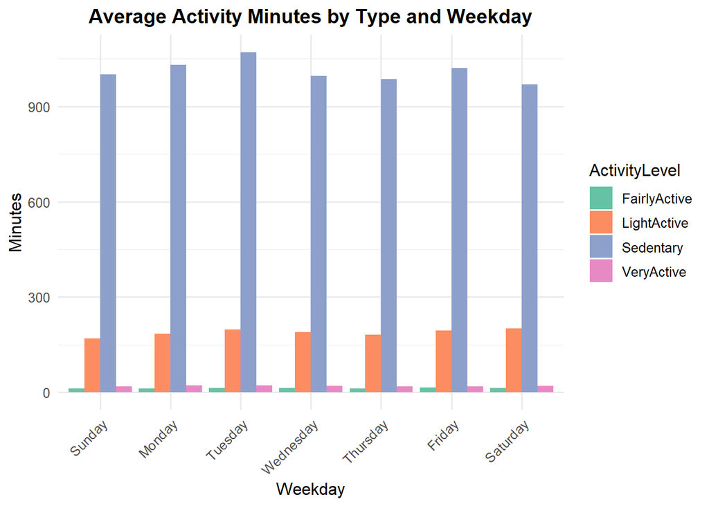

```r
activity_summary_long <- daily_activity_combined_clean %>%
  group_by(weekday) %>%
  summarise(
    VeryActive = mean(VeryActiveMinutes, na.rm = TRUE),
    FairlyActive = mean(FairlyActiveMinutes, na.rm = TRUE),
    LightActive = mean(LightlyActiveMinutes, na.rm = TRUE),
    Sedentary = mean(SedentaryMinutes, na.rm = TRUE)
  ) %>%
  pivot_longer(
    cols = c(VeryActive, FairlyActive, LightActive, Sedentary),
    names_to = "ActivityLevel",
    values_to = "Minutes"
  )

activity_summary_long$weekday <- factor(
  activity_summary_long$weekday,
  levels = c("Sunday", "Monday", "Tuesday", "Wednesday", "Thursday", "Friday", "Saturday")
)
ggplot(activity_summary_long, aes(x = weekday, y = Minutes, fill = ActivityLevel)) + geom_bar(stat = "identity", position = position_dodge()) +
  labs(
    title = "Average Activity Minutes by Type and Weekday",
    x = "Weekday",
    y = "Minutes"
  ) +
  scale_fill_brewer(palette = "Set2") +
  theme_minimal(base_size = 12) +
  theme(
    plot.title = element_text(face = "bold", size = 14, hjust = 0.5),
    axis.text.x = element_text(angle = 45, hjust = 1)
  )
```

**BMI Distribution**

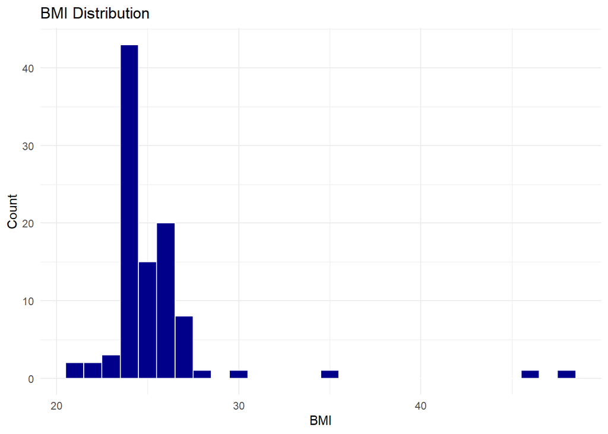

```r
ggplot(weight_log_combined, aes(x = BMI)) +
  geom_histogram(binwidth = 1, fill = "darkblue", color = "white") +
  labs(title = "BMI Distribution", x = "BMI", y = "Count") +
  theme_minimal()
```

It is crucial to acknowledge that these insights are based on a small subset of the total participants (13 out of 35). Therefore, the findings might not be fully representative of the entire user base.

While the majority of individuals are clustered in the mid-20s for BMI, there are also individuals with higher BMI values extending up to around 30, and even a few beyond that. This suggests the presence of individuals who might be classified as overweight or obese according to standard BMI categories.

**Participants categorized by body mass index**

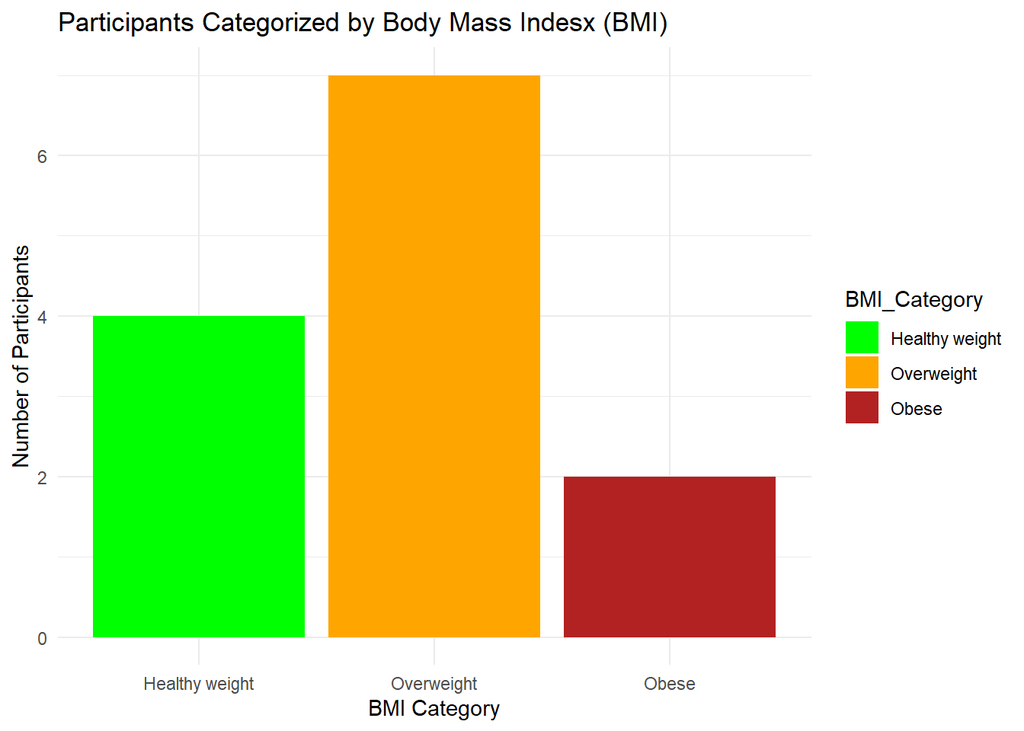

```r
bmi_counts <- weight_log_combined %>%
  mutate(
    BMI_Category = case_when(
      BMI < 18.5 ~ "Underweight",
      BMI >= 18.5 & BMI < 25 ~ "Healthy weight",
      BMI >= 25 & BMI < 30 ~ "Overweight",
      BMI >= 30 ~ "Obese"
    )) %>%
group_by(Id) %>%
  slice_tail(n=1) %>%
  ungroup() %>%
  count(BMI_Category)

bmi_counts$BMI_Category <- factor(
  bmi_counts$BMI_Category,
  levels = c("Healthy weight", "Overweight", "Obese")
)

ggplot(bmi_counts, aes(x = BMI_Category, y = n, fill = BMI_Category)) +
  geom_col() +
  labs(title = "Participants Categorized by Body Mass Indesx (BMI)",
       x = "BMI Category",
       y = "Number of Participants") +
  scale_fill_manual(values = c("Healthy weight" = "green",
                               "Overweight" = "orange",
                               "Obese" = "firebrick",
                               "Underweight" = "lightblue")) +
  theme_minimal()
```

It is crucial to acknowledge that these insights are based on a small subset of the total participants (13 out of 35). Therefore, the findings might not be fully representative of the entire user base.

Among the 13 participants with weight data, the largest group is categorized as “Overweight,” with 7 individuals. This suggests that within this limited sample, a slight majority have a BMI above the healthy range but below the obese threshold.

Even with the small sample size, the distribution shows more participants in the overweight category, followed by the healthy weight category, and the fewest in the obese category within this subset.

**Calories Burned vc. Activity Level**

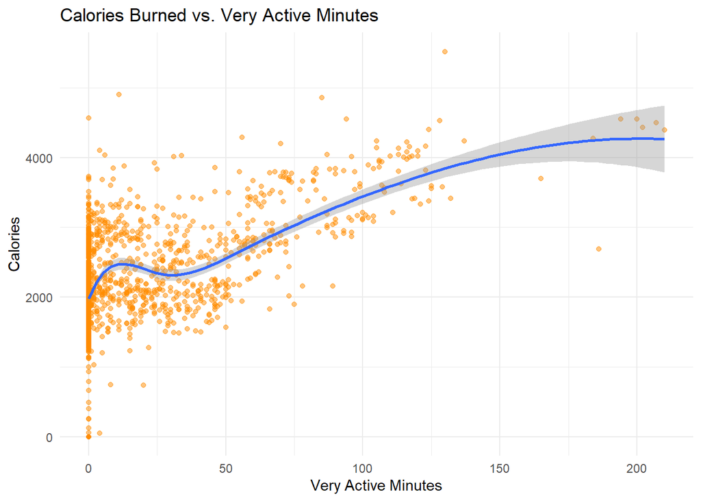

```r
activity_calories <- daily_activity_combined_clean %>%
  select(VeryActiveMinutes, FairlyActiveMinutes, LightlyActiveMinutes, SedentaryMinutes, Calories)

ggplot(activity_calories, aes(x = VeryActiveMinutes, y = Calories)) +
  geom_point(alpha = 0.5, color = "darkorange") +
  geom_smooth(method = "loess", se = TRUE) +
  labs(title = "Calories Burned vs. Very Active Minutes", x = "Very Active Minutes", y = "Calories") +
  theme_minimal()
```

The scatter plot demonstrates a clear positive correlation between very active minutes and calories burned. As the number of very active minutes increase, the number of calories burned also tends to rise. The loess smoothing line with a confidence interval (shaded area) shows a nonlinear upward trend, indicating that even moderate increases in active time can lead to significant gains in calories burned. This insights supports the idea that encouraging users to increase their very active minutes can be an effective strategy to enhance their calorie expenditure.

**Steps vc. Calories**

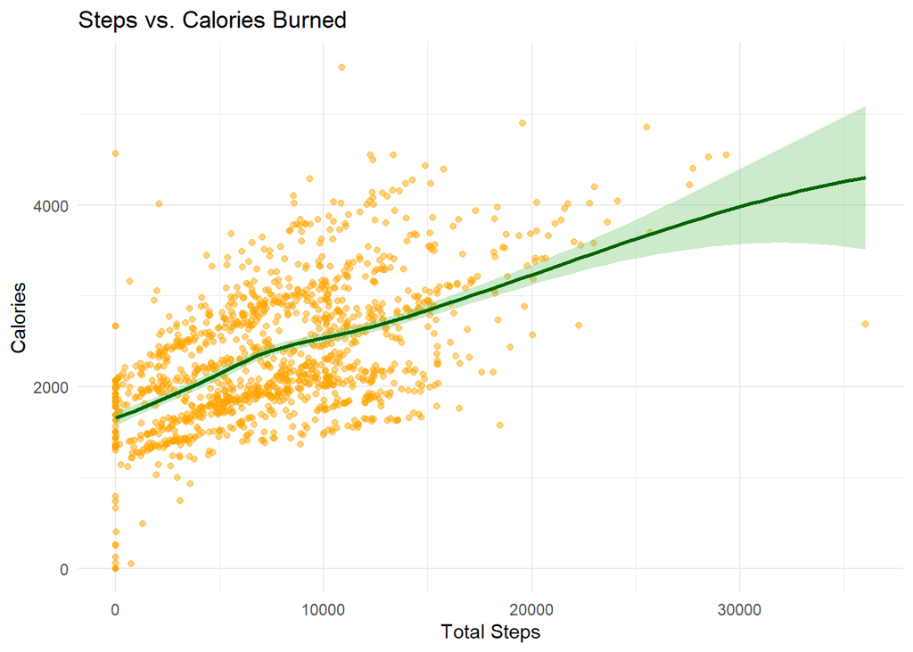

```r
ggplot(daily_activity_combined_clean, aes(x = TotalSteps, y = Calories)) +
  geom_point(alpha = 0.5, color = "orange") +
  geom_smooth(method = "loess", color = "darkgreen", fill = "palegreen3") +
  labs(title = "Steps vs. Calories Burned", x = "Total Steps", y = "Calories") +
  theme_minimal()
```

There is a strong positive correlation between total steps and calories burned. As the number of steps increases, the number of calories burned also tends to increase. The confidence interval (shaded area) widens as step count increases, suggestion greater variability in calories burned at higher activity levels. This may be due to differences in individual metabolism, workout intensity, or body weight.

**Steps vs. 10,000 Daily Goal**

For this analysis, we will use the goal of 10,000 steps per day. However, recent studies show that this number can vary — ranging from 4,000 to 18,000 steps per day for adults, and from 10,000 to 16,000 steps per day for children and adolescents.

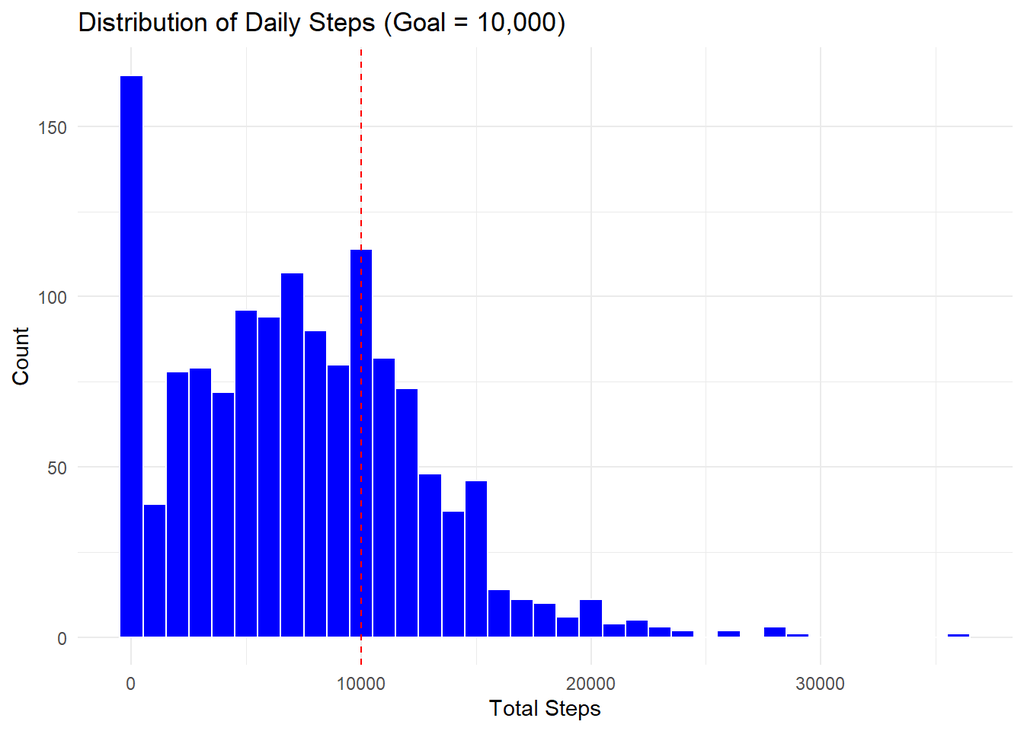

```r
daily_goal <- 10000

ggplot(daily_activity_combined_clean, aes(x = TotalSteps)) +
  geom_histogram(binwidth = 1000, fill = "blue", color = "white") +
  geom_vline(xintercept = daily_goal, color = "red", linetype = "dashed") +
  labs(title = "Distribution of Daily Steps (Goal = 10,000)", x = "Total Steps", y = "Count") +
  theme_minimal()
```

A significant number of users fall below the 10,000-step mark, indicating that most users do not meet the recommended daily goal. There is a large concentration of users with fewer than 5,000 steps, suggesting a relatively sedentary lifestyle for a considerable portion of the population. The distribution shows a gradual decline as the step count increases, with relatively few users achieving more than 15,000 steps in a day. The peak at zero or very low steps may represent days when devices were not worn or data was not properly recorded.

**Average Steps vs. Average Calories at different hours in the day**

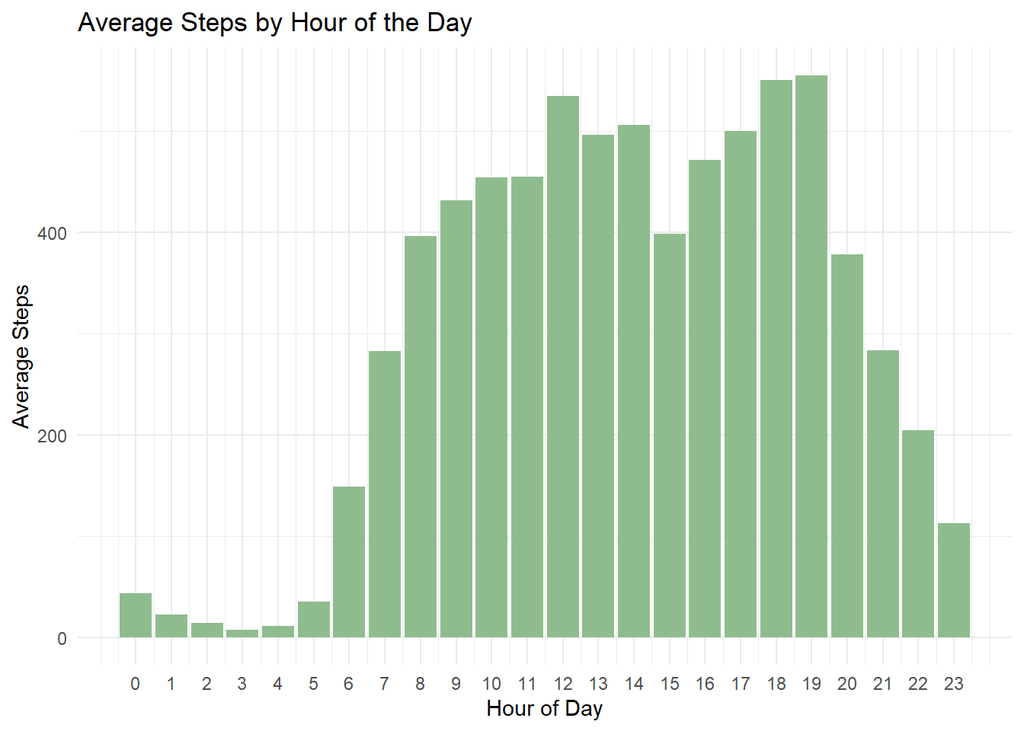

```r
hourly_by_hour <- hourly_combined %>%
  mutate(Hour = hour(ActivityHour)) %>%
  group_by(Hour) %>%
  summarise(
    AvgSteps = mean(StepTotal, na.rm = TRUE),
    AvgCalories = mean(Calories, na.rm = TRUE),
    .groups = "drop"
  )

ggplot(hourly_by_hour, aes(x = Hour, y = AvgSteps)) +
  geom_col(fill = "darkseagreen") +
  labs(title = "Average Steps by Hour of the Day",
       x = "Hour of Day",
       y = "Average Steps") +
  scale_x_continuous(breaks = 0:23) +
  theme_minimal()
```

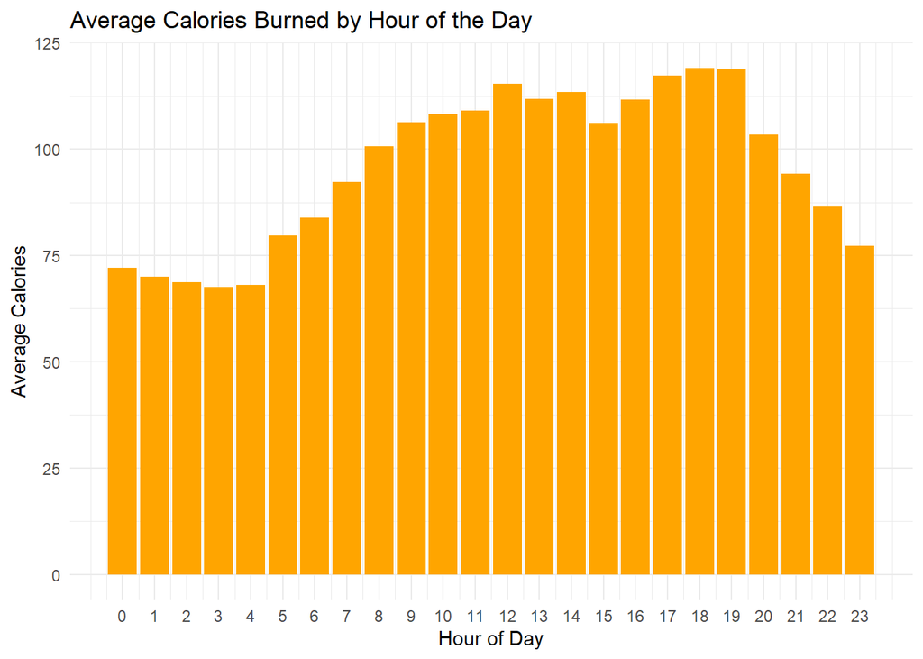

```r
ggplot(hourly_by_hour, aes(x = Hour, y = AvgCalories)) +
  geom_col(fill = "orange") +
  labs(title = "Average Calories Burned by Hour of the Day",
       x = "Hour of Day",
       y = "Average Calories") +
  scale_x_continuous(breaks = 0:23) +
  theme_minimal()
```

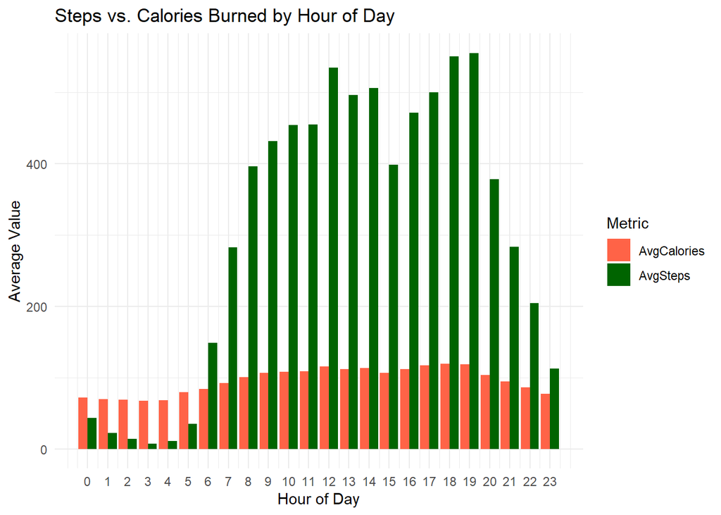

```r
hourly_summary <- hourly_combined %>%
  mutate(Hour = hour(ActivityHour)) %>%
  group_by(Hour) %>%
  summarise(
    AvgSteps = mean(StepTotal, na.rm = TRUE),
    AvgCalories = mean(Calories, na.rm = TRUE),
    .groups = "drop"
  )

hourly_long <- hourly_summary %>%
  pivot_longer(cols = c(AvgSteps, AvgCalories),
               names_to = "Variable",
               values_to = "Value")

ggplot(hourly_long, aes(x = Hour, y = Value, fill = Variable)) +
  geom_col(position = "dodge") +
  labs(title = "Steps vs. Calories Burned by Hour of Day",
       x = "Hour of Day",
       y = "Average Value",
       fill = "Metric") +
  scale_x_continuous(breaks = 0:23) +
  scale_fill_manual(values = c("AvgSteps" = "darkgreen", "AvgCalories" = "tomato")) +
  theme_minimal()
```

Correlation: There’s a noticeable positive correlation between the average number of steps taken and the average calories burned throughout the day. Periods of higher step activity correspond with higher calorie expenditure. This aligns with the understanding that more physical movement leads to burning more calories.

**Sleep Duration by Weekday**

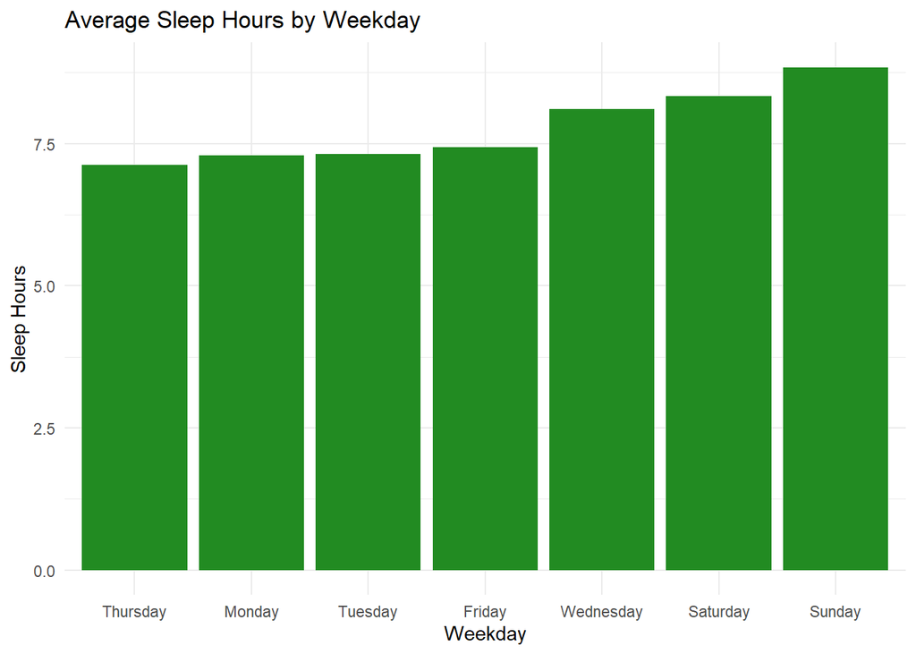

```r
sleep_weekday <- activity_sleep_merged %>%
  group_by(weekday) %>%
  summarise(avg_sleep = mean(SleepHours, na.rm = TRUE))

ggplot(sleep_weekday, aes(x = reorder(weekday, avg_sleep), y = avg_sleep)) +
  geom_bar(stat = "identity", fill = "forestgreen") +
  labs(title = "Average Sleep Hours by Weekday", x = "Weekday", y = "Sleep Hours") +
  theme_minimal()
```

The most prominent observation is the increase in average sleep hours on the weekends (Saturday and Sunday) compared to the weekdays. Users appear to sleep significantly longer on these days, indicating a tendency to catch up on rest.

Interestingly, Thursday shows the lowest average sleep hours among all the weekdays presented. This could be due to various factors, such as mid-week fatigue or social engagements extending into the late evening. Further investigation might be needed to understand this specific trend.

Sunday exhibits the highest average sleep hours, surpassing Saturday. This might suggest that users take the opportunity to have the longest sleep on the final day of the weekend before the start of the new week.

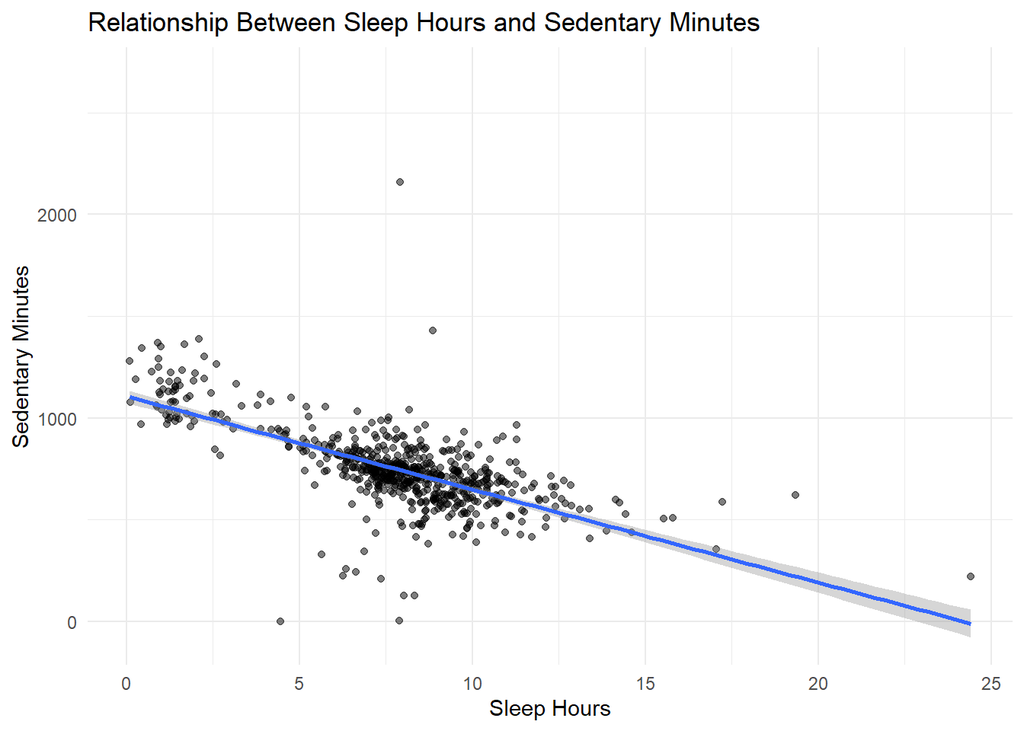

```r
ggplot(activity_sleep_merged, aes(x = SleepHours, y = SedentaryMinutes)) +
  geom_point(alpha = 0.5) +
  geom_smooth(method = "lm") +
  labs(title = "Relationship Between Sleep Hours and Sedentary Minutes", x = "Sleep Hours", y = "Sedentary Minutes") +
  theme_minimal()
```

The graph displays a clear negative correlation between the number of sleep hours and the number of sedentary minutes. As sleep hours increase, the number of sedentary minutes tends to decrease, and vice versa.

Individuals who report fewer hours of sleep tend to have a higher number of sedentary minutes. This could suggest that those with less sleep might feel more fatigued during the day and engage in more sedentary behaviors.

Conversely, individuals who sleep for longer durations tend to have fewer sedentary minutes. This might indicate that sufficient sleep contributes to higher energy levels and a greater propensity for being active rather than sedentary.

*Act*

2. How can these trends be applied to Bellabeat customers? Although the dataset does not specify users’ gender, Bellabeat primarily targets women. Therefore, all insights and recommendations are tailored with this audience in mind.

The analysis of smart device usage reveals key behavioral patterns related to physical activity, sleep, and sedentary time. These findings can support the development of personalized features and wellness strategies for Bellabeat’s users:

Timing of Activity: Users tend to be most active during standard daytime hours. Bellabeat can leverage this by sending motivational prompts or recommending ideal workout times based on individual habits.

Steps and Calorie Trends: Most users fall short of the recommended 10,000 steps per day. Introducing features like a “Daily Step Streak” can encourage consistency and incremental progress.

Sedentary Behavior and Sleep Patterns: A segment of users displays both high sedentary time and poor sleep. Personalized interventions promoting better sleep hygiene and regular movement can help improve overall well-being.

Correlations for Coaching: The negative correlation between sleep duration and sedentary minutes suggests that promoting healthy sleep habits could reduce inactivity. Bellabeat could integrate behavior-based coaching to support these improvements.

3. How can these trends influence Bellabeat’s marketing strategy? Based on the analysis, the following marketing strategies are recommended to increase engagement and promote healthier lifestyles:

Smart Reminders: Use inactivity alerts to encourage movement, especially during low-activity periods. This aligns with users’ typical daily routines and can boost step counts.

Goal Setting + Rewards: Offer personalized fitness goals with gamified rewards (e.g., badges or streaks) to enhance motivation and satisfaction.

Community Engagement: Include in-app social features that allow users to share progress and support one another. Social accountability can help sustain healthy habits.

Sleep Behavior Support: Promote content and features that educate users on sleep hygiene, while encouraging reduced sedentary time through timely prompts and wellness tips.

Educational Content: Share actionable health insights via blogs, articles, and notifications to help users make informed lifestyle decisions.

To validate these strategies, Bellabeat could prototype the new features and conduct A/B testing to evaluate user response and optimize effectiveness.